# Exponential Smoothing

# 7.1

Data set books contains the daily sales of paperback and hardcover books at the same store. The task is to forecast the next four days’ sales for paperback and hardcover books (data set books).

1. Plot the series and discuss the main features of the data.

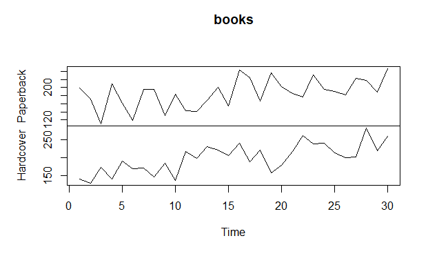

```r
library(fma)
library(tidyverse)
library(ggfortify)
books <- fma::books
plot(books)
```

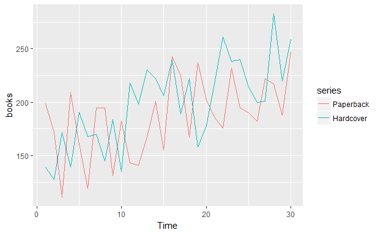

```r
autoplot(books)
```

> The data appears to have some seasonal variance and there appears to be times where Paperback is at the opposite extreme of the Hardcover books.
2. Use simple exponential smoothing with the ses function (setting initial=“simple”) and explore different values of $\alpha$ for the paperback series. Record the within-sample SSE for the one-step forecasts. Plot SSE against $\alpha$ and find which value of $\alpha$ works best. What is the effect of $\alpha$ on the forecasts?

```r
paperback <- books[,1]
fit1 <- ses(paperback, alpha=0.4, initial="simple", h=3)
fit2 <- ses(paperback, alpha=0.6, initial="simple", h=3)
fit3 <- ses(paperback, alpha=0.8, h=3)
plot(fit1, ylab="Paperback Books Sold",
  xlab="Time Series", main="", fcol="white", type="o")
lines(fitted(fit1), col="blue", type="o")
```

```r
lines(fitted(fit2), col="red", type="o")
lines(fitted(fit3), col="green", type="o")
```

```r
lines(fit1$mean, col="blue", type="o")
lines(fit2$mean, col="red", type="o")
```

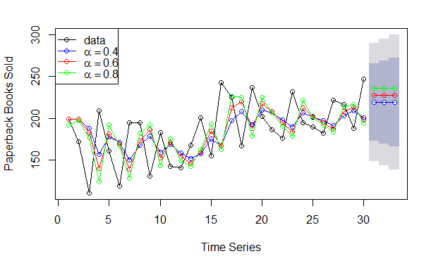

```r
lines(fit3$mean, col="green", type="o")
legend("topleft",lty=1, col=c(1,"blue","red","green"),
  c("data", expression(alpha == 0.4), expression(alpha == 0.6),
  expression(alpha == 0.8)),pch=1)
```

> Due to so much variability in the data, it’s challenging to tell which worked best. The best performance would be what I was trying to achive with my results, I would say $\alpha = 0.4$ looks to be the best predictor but $\alpha = 0.8$ appears to be the safest assumption for the next best value.
3. Now let ses select the optimal value of $\alpha$ Use this value to generate forecasts for the next four days. Compare your results with 2.

```r
fit_opt <- ses(paperback, initial="simple", h=4)
plot(fit_opt, ylab="Paperback Books Sold",
  xlab="Time Series", main="", fcol="white", type="o")
lines(fitted(fit_opt), col="blue", type="o")
```

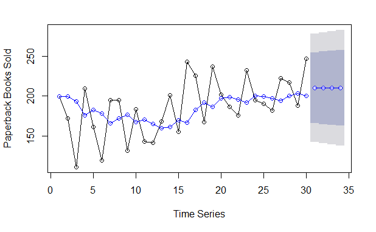

```r
lines(fit_opt$mean, col="blue", type="o")
```

```r
summary(fit_opt)
```

```
Forecast method: Simple exponential smoothing

Model Information:
Simple exponential smoothing

Call:
 ses(y = paperback, h = 4, initial = "simple")

  Smoothing parameters:
    alpha = 0.2125

  Initial states:
    l = 199

  sigma:  34.7918
Error measures:
                   ME     RMSE      MAE       MPE     MAPE      MASE       ACF1
Training set 1.749509 34.79175 28.64424 -2.770157 16.56938 0.7223331 -0.1268119

Forecasts:
   Point Forecast    Lo 80    Hi 80    Lo 95    Hi 95
31       210.1537 165.5663 254.7411 141.9631 278.3443
32       210.1537 164.5706 255.7368 140.4404 279.8671
33       210.1537 163.5962 256.7112 138.9501 281.3573
34       210.1537 162.6418 257.6657 137.4905 282.8170
```

> The optimal alpha for the paperback books is $\alpha$ = 0.2125
4. Repeat but with initial=“optimal”. How much difference does an optimal initial level make?

```r
fit_opt <- ses(paperback, initial="optimal", h=4)
plot(fit_opt, ylab="Paperback Books Sold",
  xlab="Time Series", main="", fcol="white", type="o")
lines(fitted(fit_opt), col="blue", type="o")
```

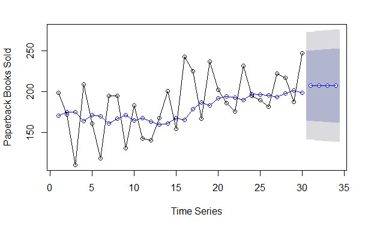

```r
lines(fit_opt$mean, col="blue", type="o")
```

```r
summary(fit_opt)
```

```
Forecast method: Simple exponential smoothing

Model Information:
Simple exponential smoothing

Call:
 ses(y = paperback, h = 4, initial = "optimal")

  Smoothing parameters:
    alpha = 0.1685

  Initial states:
    l = 170.8257

  sigma:  33.6377

     AIC     AICc      BIC
318.9747 319.8978 323.1783

Error measures:
                   ME     RMSE     MAE       MPE     MAPE      MASE       ACF1
Training set 7.176212 33.63769 27.8431 0.4737524 15.57782 0.7021303 -0.2117579

Forecasts:
   Point Forecast    Lo 80    Hi 80    Lo 95    Hi 95
31       207.1098 164.0013 250.2182 141.1811 273.0384
32       207.1098 163.3934 250.8261 140.2513 273.9682
33       207.1098 162.7937 251.4258 139.3342 274.8853
34       207.1098 162.2021 252.0174 138.4294 275.7901
```

> The optimal alpha with the setting of optimal in ses = “optimal” is $\alpha = 0.1685$
5. Repeat steps (b)-(d) with the hardcover series.

### Hardcover books

b2. Use simple exponential smoothing with the ses function (setting initial=“simple”) and explore different values of $\alpha$ for the paperback series. Record the within-sample SSE for the one-step forecasts. Plot SSE against $\alpha$ and find which value of $\alpha$ works best. What is the effect of $\alpha$ on the forecasts?

```r
hardcover <- books[,2]
fit1 <- ses(hardcover, alpha=0.4, initial="simple", h=3)
fit2 <- ses(hardcover, alpha=0.6, initial="simple", h=3)
fit3 <- ses(hardcover, alpha=0.8, h=3)
plot(fit1, ylab="Hardcover Books Sold",
  xlab="Time Series", main="", fcol="white", type="o")
lines(fitted(fit1), col="blue", type="o")
```

```r
lines(fitted(fit2), col="red", type="o")
lines(fitted(fit3), col="green", type="o")
```

```r
lines(fit1$mean, col="blue", type="o")
lines(fit2$mean, col="red", type="o")
```

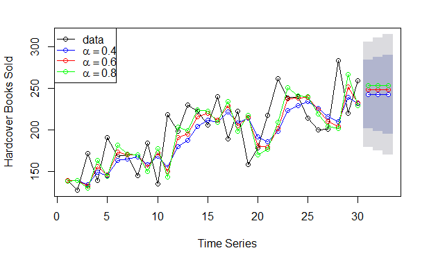

```r
lines(fit3$mean, col="green", type="o")
legend("topleft",lty=1, col=c(1,"blue","red","green"),
  c("data", expression(alpha == 0.4), expression(alpha == 0.6),
  expression(alpha == 0.8)),pch=1)
```

> Due to so much variability in the data, it’s challenging to tell which worked best in the hardcover as well. The best performance would be what I was trying to achieve with my results, so I would say $\alpha = 0.4$ appears to be the safest assumption for the next best value but $\alpha = 0.8$ looks like it could be a more accurate prediction.

c2. Now let ses select the optimal value of $\alpha$ Use this value to generate forecasts for the next four days. Compare your results with 2.

```r
fit_opt <- ses(hardcover, initial="simple", h=4)
plot(fit_opt, ylab="Hardcover Books Sold",
  xlab="Time Series", main="", fcol="white", type="o")
lines(fitted(fit_opt), col="blue", type="o")
```

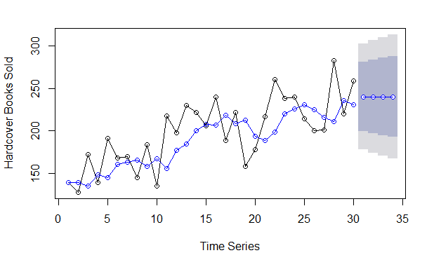

```r
lines(fit_opt$mean, col="blue", type="o")
```

```r
summary(fit_opt)
```

```
Forecast method: Simple exponential smoothing

Model Information:
Simple exponential smoothing

Call:
 ses(y = hardcover, h = 4, initial = "simple")

  Smoothing parameters:
    alpha = 0.3473

  Initial states:
    l = 139

  sigma:  32.0198
Error measures:
                  ME     RMSE      MAE      MPE     MAPE      MASE       ACF1
Training set 9.72952 32.01982 26.34467 3.104211 13.05063 0.7860035 -0.1629042

Forecasts:
   Point Forecast    Lo 80    Hi 80    Lo 95    Hi 95
31       240.3808 199.3457 281.4158 177.6231 303.1385
32       240.3808 196.9410 283.8206 173.9453 306.8162
33       240.3808 194.6625 286.0990 170.4608 310.3008
34       240.3808 192.4924 288.2691 167.1418 313.6197
```

> The optimal alpha for the hardcover books is $\alpha$ = 0.3473$ which fits in line with my previous thoughts on best alpha
4. Repeat but with initial=“optimal”. How much difference does an optimal initial level make?

```r
fit_opt <- ses(hardcover, initial="optimal", h=4)
plot(fit_opt, ylab="Paperback Books Sold",
  xlab="Time Series", main="", fcol="white", type="o")
lines(fitted(fit_opt), col="blue", type="o")
```

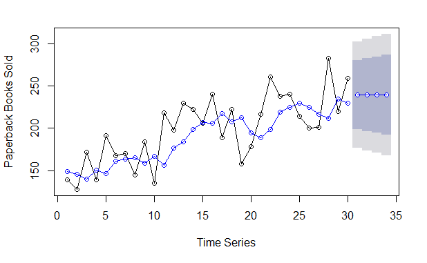

```r
lines(fit_opt$mean, col="blue", type="o")
```

```r
summary(fit_opt)
```

```
Forecast method: Simple exponential smoothing

Model Information:
Simple exponential smoothing

Call:
 ses(y = hardcover, h = 4, initial = "optimal")

  Smoothing parameters:
    alpha = 0.3283

  Initial states:
    l = 149.2836

  sigma:  31.931

     AIC     AICc      BIC
315.8506 316.7737 320.0542

Error measures:
                   ME     RMSE     MAE      MPE     MAPE      MASE       ACF1
Training set 9.166918 31.93101 26.7731 2.636328 13.39479 0.7987858 -0.1417817

Forecasts:
   Point Forecast    Lo 80    Hi 80    Lo 95    Hi 95
31       239.5602 198.6390 280.4815 176.9766 302.1439
32       239.5602 196.4905 282.6299 173.6908 305.4297
33       239.5602 194.4443 284.6762 170.5613 308.5591
34       239.5602 192.4869 286.6336 167.5677 311.5527
```

# 7.3

For this exercise, use the quarterly UK passenger vehicle production data from 1977:1–2005:1 (data set ukcars).

1. Plot the data and describe the main features of the series.

```r
library(expsmooth)
ukcars <- expsmooth::ukcars
```

2. Decompose the series using STL and obtain the seasonally adjusted data.

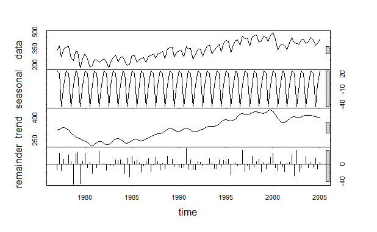

```r
fit_stl <- stl(ukcars, s.window = "periodic")
plot(fit_stl)
```

> We see a long gradual upwards trend from ~1980 to ~2000 followed by a drop and gradual trend upwards.

```r
sadj <- seasadj(fit_stl)
sfactors <- fit_stl$time.series[2:11, "seasonal"]  # Acquire the seasonal Factors
```

3. Forecast the next two years of the series using an additive damped trend method applied to the seasonally adjusted data. Then reseasonalize the forecasts. Record the parameters of the method and report the RMSE of the one-step forecasts from your method.

```r
paste0("Additive damped RMSE : ",round(accuracy(fit_dpd_sadj)[2], 3))
```

```
[1] "Additive damped RMSE : 25.14"
```

```r
rsfit_dpd_sadj <- fit_dpd_sadj$mean + sfactors
rsfit_dpd_sadj
```

```
         Qtr1     Qtr2     Qtr3     Qtr4
2005          427.4678 361.3282 404.8962
2006 432.1189 427.4660 361.3266 404.8947
2007 432.1175 427.4648 361.3255
```

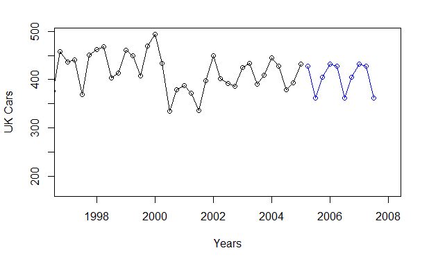

```r
plot(ukcars,
     type = "o",
     xlab = "Years",
     ylab = "UK Cars",
     xlim = c(1997, 2008))
lines(rsfit_dpd_sadj, type = "o", col = "blue")
```

> The results are very impressive, it produced a very reasonable forcast excluding any shock events.
4. Forecast the next two years of the series using Holt’s linear method applied to the seasonally adjusted data. Then reseasonalize the forecasts. Record the parameters of the method and report the RMSE of of the one-step forecasts from your method.

```r
paste0("Holt Linear Method with seasonal adjustment RMSE: ",round(accuracy(fit_hl)[2],3))
```

```
[1] "Holt Linear Method with seasonal adjustment RMSE: 25.314"
```

> RSME

> Reseaonalize the forecast

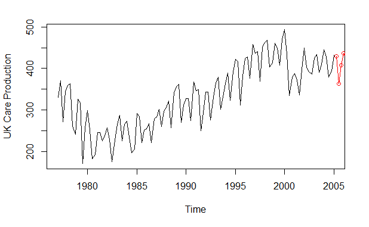

```r
rs_l <- fit_hl$mean + sfactors
plot(ukcars, ylab = "UK Care Production")
lines(rs_l, type = "o", col = "red")
```

5. Now use ets() to choose a seasonal model for the data.

```r
fit_ets <- ets(ukcars, model = "ANN")
summary(fit_ets)
```

```
ETS(A,N,N)

Call:
 ets(y = ukcars, model = "ANN")

  Smoothing parameters:
    alpha = 0.2836

  Initial states:
    l = 326.0531

  sigma:  42.1043

     AIC     AICc      BIC
1385.469 1385.689 1393.651

Training set error measures:
                   ME     RMSE      MAE      MPE    MAPE
Training set 2.703015 42.10435 35.15604 -1.00922 11.5752
                 MASE      ACF1
Training set 1.145718 0.0830777
```

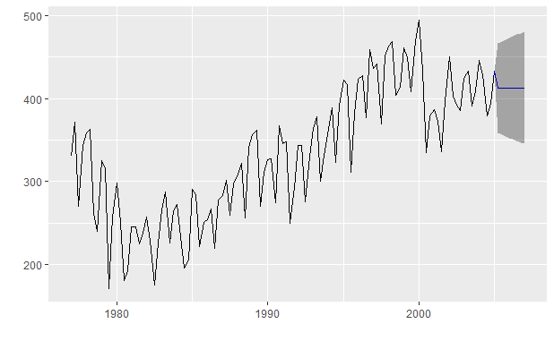

```r
autoplot(forecast(fit_ets), xlab = "Years", ylab = "UK Car Production")
```

```r
paste0("RMSE from Simple Exp Smoothing Method: ",round(accuracy(fit_ets)[2], 3))
```

```
[1] "RMSE from Simple Exp Smoothing Method: 42.104"
```

6. Compare the RMSE of the fitted model with the RMSE of the model you obtained using an STL decomposition with Holt’s method. Which gives the better in-sample fits?

```r
paste0("Additive Damped - RMSE : ",round(accuracy(fit_dpd_sadj)[2], 3))
```

```
[1] "Additive Damped - RMSE : 25.14"
```

```r
paste0("Holt -  RMSE: ",round(accuracy(fit_hl)[2],3))
```

```
[1] "Holt -  RMSE: 25.314"
```

```r
paste0("RMSE from Simple Exp Smoothing Method: ",round(accuracy(fit_ets)[2], 3))
```

```
[1] "RMSE from Simple Exp Smoothing Method: 42.104"
```

7. Compare the forecasts from the three approaches? Which seems most reasonable?

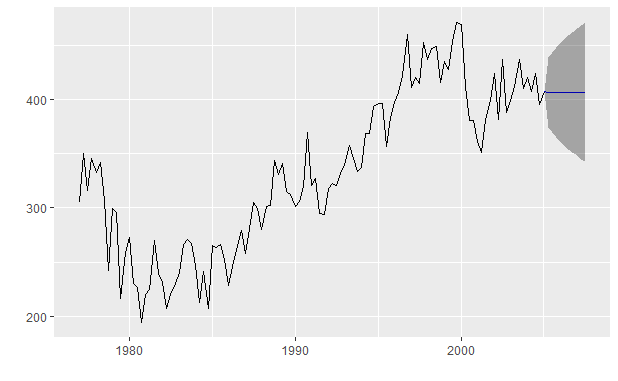

```r
autoplot(forecast(fit_dpd_sadj))
```

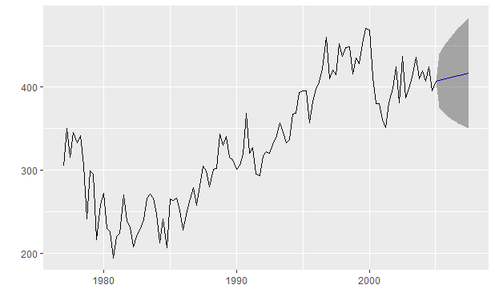

```r
autoplot(forecast(fit_hl))
```

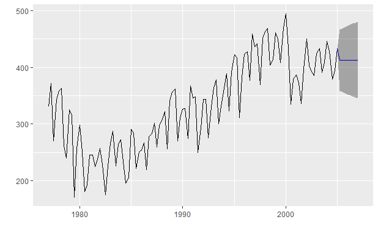

```r
autoplot(forecast(fit_ets))
```

> I find this a difficult evaluation on the most appropriate model. Using our evaluation methods the lowest RMSE is the Additive Damped model but visually the second Holt model appears to have the more accurate prediction. I think this is an interesting dilemma because the comparison measure indicates that the first model is best but the visuals of the second model look more sound and there is a conflict with my intiuition and the data. The first model with the lowest RMSE is the most reasonable choice. I did not discuss the simple exponential smoothing method because its performance is clearly subpar.